# OxyR

Fold-switch pair **4xwsD_4y0mJ** — **4xwsD** vs **4y0mJ**

Pseudomonas aeruginosa PAO1

## Figure 1: Phylogenetic tree with per-cluster fold-preference heatmap.

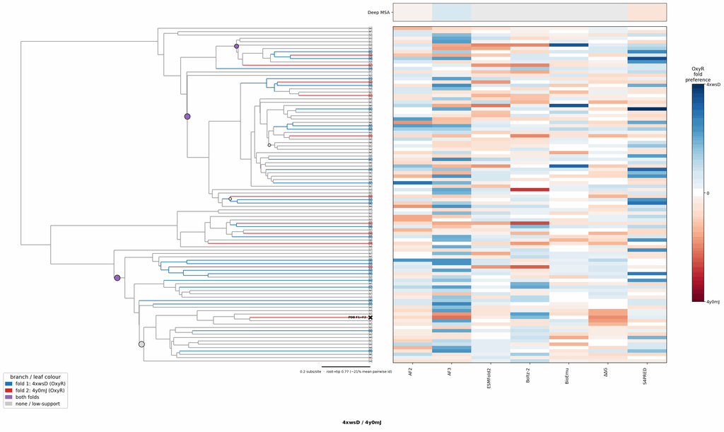

## Figure 2: Aligned overlay (both folds superposed)

The single fold-switching chain of each fold superposed by TM-align; waters hidden, any ligand shown as green sticks. Grey = structurally conserved core, colour = divergent (fold-switching) region.

4xwsD (OxyR)4y0mJ (OxyR)Ligand MSE (bound to 4y0mJ)

TM-score: 0.932 · Trigger class: ligand

Aligned overlay

Loading...

## Figure 3: The two folds, side by side

Each fold is coloured by per-residue Cα deviation between the two superposed structures: grey ≈ conserved core, full colour = structurally divergent (fold-switching) region.

4xwsD (OxyR)

4y0mJ (OxyR)

0 Å5≥10 Å

4xwsD (OxyR)

Loading...

4y0mJ (OxyR)

Loading...

## Figure 4: Best-cluster predicted contact maps over the two true folds.

Predicted contact maps (MSA-Transformer) for the clusters best matching each fold, over the true contacts of fold 1 (upper triangle) and fold 2 (lower). Divergent contacts between clusters are the contact-level signature of fold-switching.

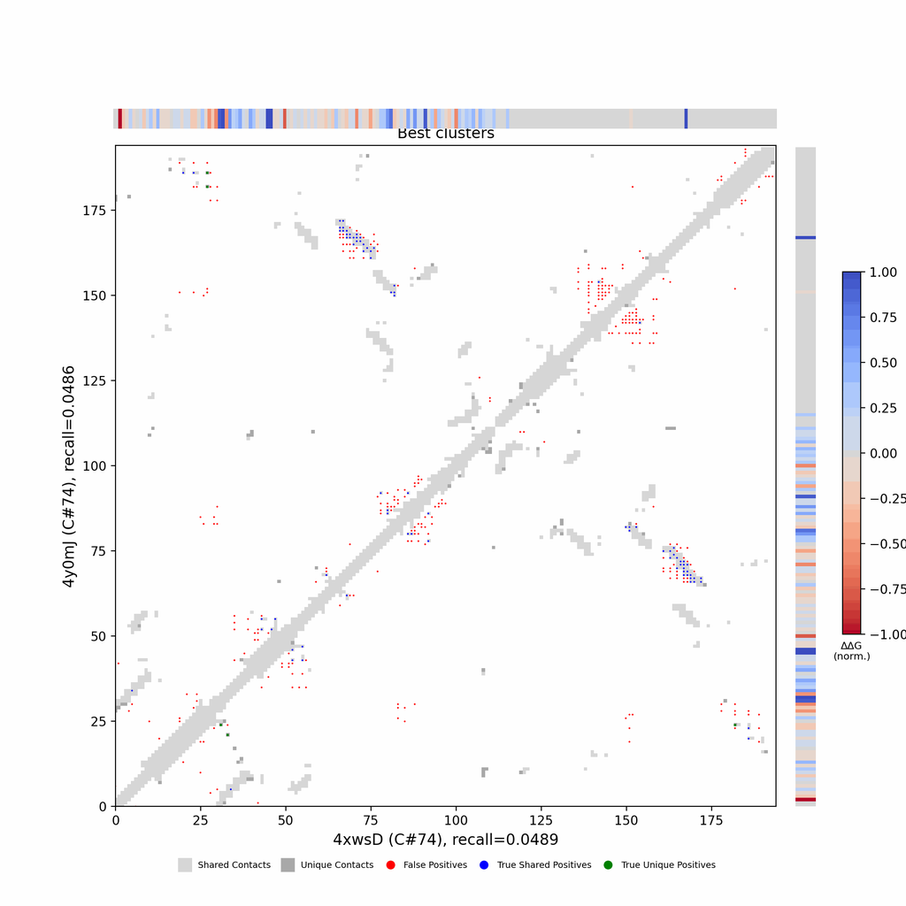

## Figure 5: Per-residue ΔΔG fold-preference contribution

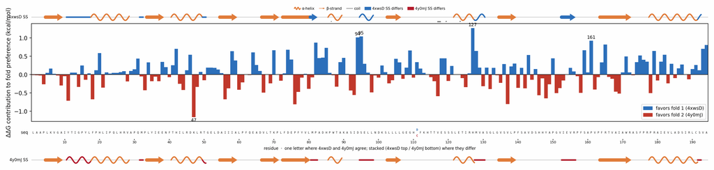

**More figures**

## Figure 6: Deep-MSA contact map panel / Best clusters contact map panel

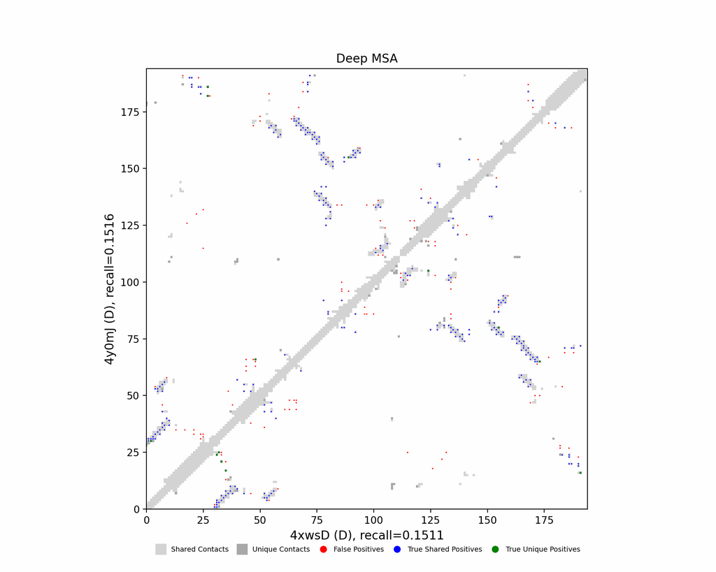

Deep-MSA contact map panel

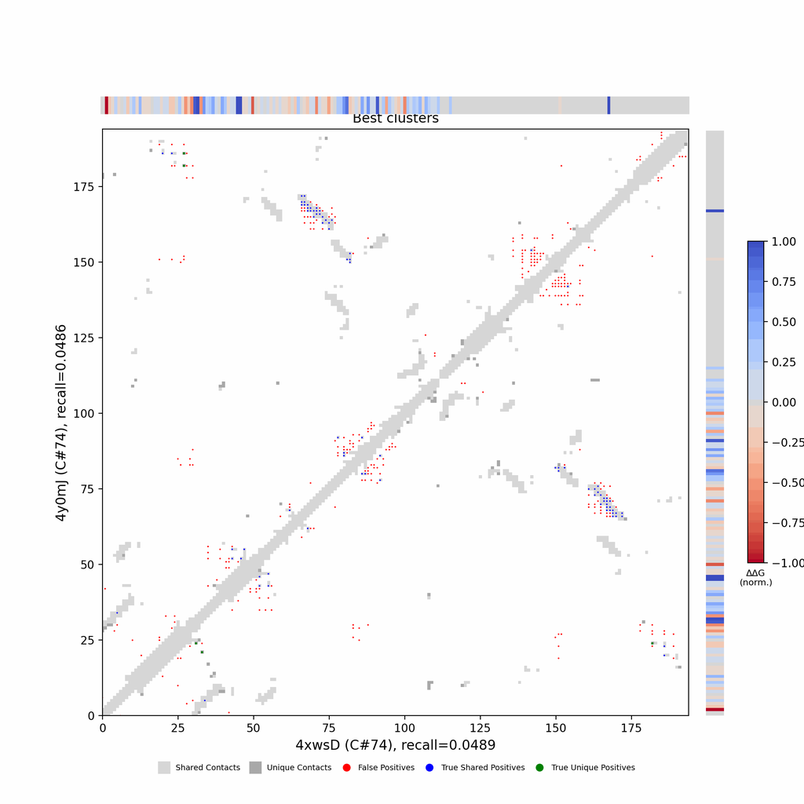

Best clusters contact map panel

## Figure 7: All clusters contact-map mosaic (small multiples).

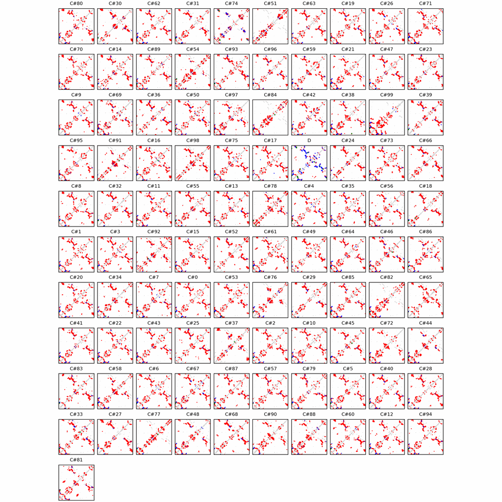

## Figure 8: Phylo null: tree with shuffled cluster fold labels.

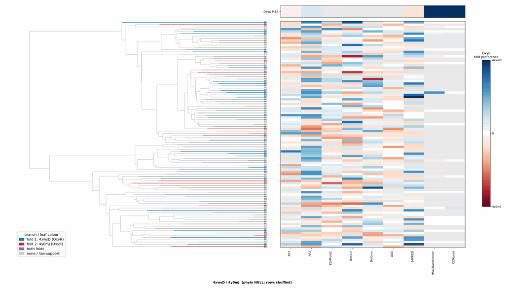

## Cluster metrics table

Per-cluster metrics underlying the figures above.

| cluster | n | neff | AF2_TM1 | AF2_TM2 | AF3_TM1 | AF3_TM2 | RE-MSAT-COM | RE-MSAT1 | RE-MSAT2 | ESM_SEQIDS | ESM_TM1 | ESM_TM2 | ΔΔG_Bias | ΔΔG_Bias_std | ΔΔG_frac_F1 | Boltz2_pref | S4PRED_pref | CCMpred_pref | BioEmu_pref |
| --- | --- | --- | --- | --- | --- | --- | --- | --- | --- | --- | --- | --- | --- | --- | --- | --- | --- | --- | --- |
| Deep | - | - | 0.95 | 0.95 | 0.96 | 0.94 | - | 0.51 | 0.19 | - | - | - | - | - | - | - | -0.0 | 0.14 | - |
| 000 | 1120.0 | 654.0 | 0.28 | 0.27 | 0.82 | 0.76 | 0.09 | 0.07 | 0.07 | 002; 004; 004; 006; 006; 002; 001; 005; 001; 005 | 0.88 ± 0.01 | 0.82 ± 0.04 | 14.58 | 4.88 | 1.0 | 0.01 | -0.02 | 0.02 | -0.02 |
| 001 | 630.0 | 380.0 | 0.37 | 0.35 | 0.84 | 0.77 | 0.08 | 0.07 | 0.07 | 003; 003; 006; 006; 004; 007; 007; 004; 001; 001 | 0.88 ± 0.03 | 0.84 ± 0.04 | 16.02 | 5.59 | 1.0 | 0.01 | 0.01 | 0.01 | 0.02 |
| 002 | 613.0 | 151.0 | 0.38 | 0.34 | 0.4 | 0.38 | 0.09 | 0.05 | 0.06 | 005; 005; 009; 009; 006; 006; 001; 002; 002; 001 | 0.88 ± 0.02 | 0.83 ± 0.04 | 14.16 | 7.6 | 1.0 | 0.02 | -0.02 | 0.0 | -0.01 |
| 003 | 591.0 | 256.0 | 0.34 | 0.31 | 0.89 | 0.83 | 0.09 | 0.07 | 0.08 | 001; 005; 005; 001; 004; 004; 007; 007; 008; 008 | 0.87 ± 0.02 | 0.84 ± 0.03 | 14.33 | 6.24 | 1.0 | 0.01 | -0.01 | 0.0 | 0.0 |
| 004 | 483.0 | 321.0 | 0.82 | 0.77 | 0.88 | 0.81 | 0.07 | 0.08 | 0.07 | 001; 001; 004; 004; 008; 008; 006; 006; 002; 002 | 0.86 ± 0.04 | 0.83 ± 0.04 | 15.41 | 4.96 | 1.0 | 0.02 | -0.0 | 0.0 | 0.03 |
| 005 | 411.0 | 142.0 | 0.38 | 0.35 | 0.42 | 0.4 | 0.05 | 0.05 | 0.05 | 004; 004; 001; 001; 006; 006; 002; 002; 005; 003 | 0.86 ± 0.04 | 0.83 ± 0.04 | 7.65 | 3.14 | 1.0 | 0.0 | -0.02 | 0.0 | 0.01 |
| 006 | 387.0 | 190.0 | 0.28 | 0.26 | 0.43 | 0.4 | 0.09 | 0.07 | 0.07 | 005; 005; 001; 007; 007; 001; 003; 003; 002; 002 | 0.85 ± 0.04 | 0.80 ± 0.04 | 13.83 | 7.13 | 1.0 | 0.02 | -0.02 | 0.0 | 0.03 |
| 007 | 379.0 | 197.0 | 0.42 | 0.41 | 0.76 | 0.67 | 0.08 | 0.08 | 0.08 | 001; 001; 007; 007; 008; 008; 006; 006; 005; 005 | 0.89 ± 0.05 | 0.85 ± 0.05 | 14.92 | 6.46 | 1.0 | 0.02 | -0.01 | 0.0 | 0.02 |
| 008 | 350.0 | 218.0 | 0.3 | 0.28 | 0.81 | 0.73 | 0.06 | 0.05 | 0.07 | 005; 005; 001; 001; 002; 002; 004; 004; 008; 008 | 0.83 ± 0.06 | 0.78 ± 0.06 | 14.98 | 5.61 | 1.0 | 0.01 | -0.02 | 0.0 | 0.01 |
| 009 | 310.0 | 155.0 | 0.33 | 0.32 | 0.42 | 0.4 | 0.06 | 0.05 | 0.06 | 006; 006; 001; 001; 007; 007; 008; 008; 004; 004 | 0.86 ± 0.03 | 0.82 ± 0.03 | 12.66 | 3.8 | 1.0 | 0.02 | 0.0 | 0.0 | -0.02 |
| 010 | 282.0 | 189.0 | 0.26 | 0.25 | 0.8 | 0.71 | 0.1 | 0.08 | 0.09 | 009; 009; 010; 010; 007; 007; 001; 001; 002; 002 | 0.86 ± 0.03 | 0.81 ± 0.04 | 13.23 | 5.15 | 1.0 | 0.02 | 0.0 | 0.0 | -0.01 |
| 011 | 280.0 | 179.0 | 0.36 | 0.35 | 0.86 | 0.77 | 0.06 | 0.07 | 0.06 | 006; 006; 008; 008; 001; 005; 001; 005; 007; 007 | 0.89 ± 0.04 | 0.85 ± 0.05 | 13.42 | 7.46 | 0.9 | 0.02 | -0.02 | 0.0 | 0.02 |
| 012 | 268.0 | 94.0 | 0.4 | 0.37 | 0.43 | 0.39 | 0.06 | 0.05 | 0.04 | 008; 008; 004; 004; 001; 007; 001; 007; 005; 005 | 0.85 ± 0.03 | 0.82 ± 0.04 | 9.95 | 5.39 | 0.9 | 0.01 | -0.02 | 0.0 | 0.02 |
| 013 | 264.0 | 132.0 | 0.58 | 0.55 | 0.8 | 0.71 | 0.02 | 0.04 | 0.02 | 008; 008; 001; 001; 005; 005; 006; 002; 002; 006 | 0.85 ± 0.05 | 0.80 ± 0.05 | 16.35 | 6.29 | 1.0 | -0.01 | -0.01 | 0.0 | 0.01 |
| 014 | 262.0 | 154.0 | 0.6 | 0.57 | 0.87 | 0.79 | 0.04 | 0.03 | 0.04 | 008; 008; 007; 007; 006; 006; 005; 005; 004; 004 | 0.87 ± 0.03 | 0.84 ± 0.02 | 10.84 | 6.01 | 0.9 | 0.02 | -0.0 | 0.0 | 0.01 |
| 015 | 244.0 | 132.0 | 0.48 | 0.45 | 0.42 | 0.4 | 0.06 | 0.05 | 0.05 | 005; 007; 005; 007; 006; 006; 001; 001; 004; 004 | 0.82 ± 0.05 | 0.77 ± 0.06 | 12.65 | 4.92 | 1.0 | 0.02 | 0.0 | 0.0 | 0.0 |
| 016 | 242.0 | 153.0 | 0.51 | 0.48 | 0.82 | 0.73 | 0.09 | 0.06 | 0.07 | 009; 009; 006; 006; 001; 001; 007; 007; 005; 005 | 0.88 ± 0.02 | 0.85 ± 0.03 | 15.09 | 5.55 | 1.0 | 0.01 | -0.01 | 0.0 | 0.02 |
| 017 | 233.0 | 135.0 | 0.38 | 0.34 | 0.88 | 0.79 | 0.03 | 0.03 | 0.05 | 007; 007; 008; 008; 006; 006; 001; 009; 001; 009 | 0.89 ± 0.01 | 0.86 ± 0.03 | 15.48 | 7.59 | 1.0 | 0.04 | -0.01 | 0.0 | 0.02 |
| 018 | 225.0 | 87.0 | 0.26 | 0.25 | 0.29 | 0.27 | 0.03 | 0.01 | 0.01 | 008; 008; 005; 005; 007; 007; 001; 006; 001; 006 | 0.88 ± 0.02 | 0.84 ± 0.04 | 12.07 | 5.63 | 1.0 | 0.03 | -0.01 | 0.0 | 0.01 |
| 019 | 224.0 | 158.0 | 0.95 | 0.92 | 0.94 | 0.94 | 0.04 | 0.05 | 0.05 | 007; 007; 005; 006; 005; 006; 001; 001; 002; 002 | 0.87 ± 0.05 | 0.82 ± 0.06 | 15.23 | 7.18 | 0.9 | -0.0 | -0.0 | 0.0 | 0.07 |
| 020 | 218.0 | 137.0 | 0.3 | 0.28 | 0.66 | 0.61 | 0.08 | 0.07 | 0.07 | - | - | - | 15.69 | 6.33 | 1.0 | 0.01 | -0.01 | - | -0.01 |
| 021 | 213.0 | 95.0 | 0.21 | 0.21 | 0.23 | 0.21 | 0.12 | 0.09 | 0.08 | - | - | - | 13.55 | 7.58 | 1.0 | 0.02 | -0.02 | - | 0.01 |
| 022 | 210.0 | 126.0 | 0.26 | 0.24 | 0.25 | 0.22 | 0.11 | 0.09 | 0.09 | - | - | - | 12.13 | 6.43 | 1.0 | 0.01 | -0.01 | - | 0.01 |
| 023 | 203.0 | 82.0 | 0.39 | 0.36 | 0.77 | 0.69 | 0.04 | 0.04 | 0.03 | - | - | - | 12.49 | 5.18 | 1.0 | 0.02 | -0.01 | - | -0.0 |
| 024 | 200.0 | 44.0 | 0.32 | 0.31 | 0.86 | 0.77 | 0.02 | 0.01 | 0.02 | - | - | - | 6.8 | 5.43 | 0.9 | 0.02 | -0.01 | - | -0.0 |
| 025 | 198.0 | 118.0 | 0.56 | 0.53 | 0.8 | 0.72 | 0.01 | 0.01 | 0.03 | - | - | - | 10.64 | 4.03 | 1.0 | 0.02 | -0.01 | - | -0.0 |
| 026 | 196.0 | 98.0 | 0.6 | 0.57 | 0.86 | 0.77 | 0.04 | 0.05 | 0.03 | - | - | - | 15.58 | 6.81 | 1.0 | 0.01 | -0.01 | - | 0.02 |
| 027 | 193.0 | 84.0 | 0.44 | 0.42 | 0.83 | 0.76 | 0.01 | 0.02 | 0.02 | - | - | - | 15.29 | 5.94 | 1.0 | 0.02 | -0.01 | - | 0.02 |
| 028 | 191.0 | 103.0 | 0.4 | 0.38 | 0.44 | 0.42 | 0.04 | 0.03 | 0.04 | - | - | - | 13.39 | 4.49 | 1.0 | 0.01 | -0.02 | - | 0.01 |

[output cut: 71 more lines]